# Climate Change and Crop Yield

### Adding Outside Data

We can add other data to the base map. Below, we are importing the crops.csv dataset. This dataset contains data from a study that modeled crop yields under different future climate scenarios, using SRES (Special Report on Emissions) scenarios that are the precursors to the RCP pathways we discussed previously in class.

**Use the sources below to familiarize yourself with the dataset :**

*Dataset overview* : http://sedac.ciesin.columbia.edu/data/set/crop-climate-effects-climate-global-food-production/docs

- **What crops were modeled?**
- **What factors went into the modeling of crop yields?**
- **What baseline was used to calculate crop yield changes**

*Information about SRES scenarios*:

- Wikipedia gives a nice overview - https://en.wikipedia.org/wiki/Special_Report_on_Emissions_Scenarios
- A more formal overview by IPCC : http://www.ipcc.ch/ipccreports/sres/emission/index.php?idp=98
- **What are the differences between the scenarios?**
- **What are the CO<sub>2</sub> emissions associated with each scenario?**

Optional:

*Dataset Citation :* Iglesias, A., and C. Rosensweig. 2009. Effects of Climate Change on Global Food Production from SRES Emissions and Socioeconomic Scenarios. Palisades, NY: NASA Socioeconomic Data and Applications Center (SEDAC). http://dx.doi.org/10.7927/H4JM27JZ. Accessed 16 March 2018

*Published work associated with dataset :* Parrya, M.L.,C. Rosenzweig, A. Iglesias, M. Livermored, and G. Fischer. 2004. Effects of Climate Change on Global Food Production Under SRES Emissions and Socio-economic Scenarios. Global Environmental Change 14 (1): 53-67. http://dx.doi.org/10.1016/j.gloenvcha.2003.10.008.

```r
crops = read.csv("/Users/koechlic/Desktop/Courses/ClimateChange_Sp2018/Datasets/crops2.csv") #importing dataset - you will need to do this with the dataset from Moodle

head(crops) #looking at top two entries in the dataset
```

```
##   X                 Country ISO3v10  crop measure scenario    year
## 1 1             Afghanistan     AFG Wheat  Actual  NoModel Current
## 2 2 Alaska (same as Canada)     USA Wheat  Actual  NoModel Current
## 3 3                 Albania     ALB Wheat  Actual  NoModel Current
## 4 4                 Algeria     DZA Wheat  Actual  NoModel Current
## 5 5                  Angola     AGO Wheat  Actual  NoModel Current
## 6 6               Argentina     ARG Wheat  Actual  NoModel Current
##         value
## 1  2750142.86
## 2
## 3   274685.71
## 4  2157083.86
## 5     4000.00
## 6 14503088.71
```

```r
unique(crops$crop) #Different crops analyzed in the study
```

```
## [1] Wheat Rice  Maize Grain
## Levels: Grain Maize Rice Wheat
```

```r
unique(crops$measure) #Measures calculated from study.  "Actual" - actual crop yield in tons, "Yield Change" - crop yield change (%) from baseline, "Percent Total Grain" - percent of total grain production from an individual crop type.
```

```
## [1] Actual            YieldChange       PercentTotalGrain
## Levels: Actual PercentTotalGrain YieldChange
```

```r
unique(crops$scenario) #Climate change scenarios
```

```
## [1] NoModel A1FI    A2a     B1a     B2a
## Levels: A1FI A2a B1a B2a NoModel
```

```r
unique(crops$year) #Year used for modeling projections
```

```
## [1] Current 2020    2050    2080
## Levels: 2020 2050 2080 Current
```

**What are the benefits of a tidy dataset for this dataset?**

**Before continuing, make sure you understand the different variables contained within the dataset (you may need to revisit sources or ask). A good test is to see if you can come up with an idea for a figure or two from values in the dataset**

### Joining Datasets

Now we will join the crops dataset with the shapefile information contained in the `Worldshapes2` dataframe. The `left_join()` and `filter` functions are from the dplyr library.

```r
crops2 <-  plyr::rename(crops, c("ISO3v10" = "adm0_a3" ))
#renaming the crops column containing the alpha 3 country code (ISO3v10) in the crops dataset to the name of the alpha 3 country code column in the Worldshapes 2 dataset. This will allow us to join the two datasets.

Worldshapes3 <- left_join(Worldshapes2, crops2, by = "adm0_a3")
#joins the Worldshapes2 and crops.tidy.3 datasets by the alpha 3 country code. This will produce a dataset with all rows from Worldshapes2 and all columns from Worldshapes2 plus columns from crops.tidy.3 that match to the country codes in Worldshapes2.
```

**Take a look at the size of Worldshapes3 by looking at the number of observations listed in your global environment (the top right box in the Rstudio window)**

One more preparatory step…

If we take a look at the value variable in our dataset, we see that it is recorded as a factor. We know, however, that these are actually continuous, numerical values. If we don’t change the type of variable from factor to numeric, we’ll have some problems graphing down the road (ex. applying a continous color scale to a factor raises errors), so let’s change it!

```r
str(Worldshapes3$value) #looking at the variable type
```

```
##  Factor w/ 6000 levels "","-0.01","-0.02",..: NA NA NA NA NA NA NA NA NA NA ...
```

```r
Worldshapes3$value = as.numeric(levels(Worldshapes3$value))[Worldshapes3$value]
#converting from factor to numeric
```

```r
tail(Worldshapes3) #Let's take a look.
```

```
##             long       lat order  hole piece group  id scalerank
## 8682790 31.28789 -22.40205   170 FALSE     1 240.1 240         1
## 8682791 31.28789 -22.40205   170 FALSE     1 240.1 240         1
## 8682792 31.28789 -22.40205   170 FALSE     1 240.1 240         1
## 8682793 31.28789 -22.40205   170 FALSE     1 240.1 240         1
## 8682794 31.28789 -22.40205   170 FALSE     1 240.1 240         1
## 8682795 31.28789 -22.40205   170 FALSE     1 240.1 240         1
##              featurecla labelrank sovereignt sov_a3 adm0_dif level
## 8682790 Admin-0 country         3   Zimbabwe    ZWE        0     2
## 8682791 Admin-0 country         3   Zimbabwe    ZWE        0     2
## 8682792 Admin-0 country         3   Zimbabwe    ZWE        0     2
## 8682793 Admin-0 country         3   Zimbabwe    ZWE        0     2
## 8682794 Admin-0 country         3   Zimbabwe    ZWE        0     2
## 8682795 Admin-0 country         3   Zimbabwe    ZWE        0     2
##                      type    admin adm0_a3 geou_dif  geounit gu_a3 su_dif
```

[output cut: 69 more lines]

**Do we see the data we expect to see?**

#### Visualzing Final Maps

Ok - let’s map some of the data. Note that the dataset is quite large so filtering and plotting may be slightly delayed.

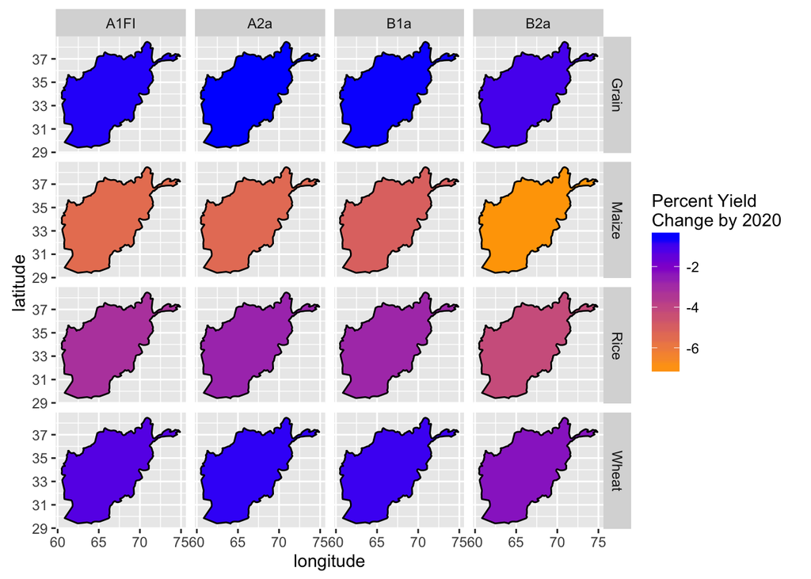

```r
Worldshapes.filtered <-  filter(Worldshapes3, measure == "YieldChange", year == 2020, Country == "Afghanistan")


 p = ggplot() +
      geom_polygon(data = Worldshapes.filtered,
        aes(x = long, y = lat, group = group, fill = (value)),
        color = "black") +
      scale_fill_continuous(name="Percent Yield \nChange by 2020",
       low = "orange", high = "blue") +
      facet_grid(crop~scenario) +
      xlab("longitude") +
      ylab("latitude")

 p
```

- **What am I plotting here?**
- **Work through the code and annotate what is going on.**
- **Play around with the low and high values in the scale for more/less effective color gradients (ex. in the first graph, replace “orange” with “light blue” - what happens to the resolution?)**
- **What trends do you notice in the figure?**

Note : fig.height and fig.width commands can be used in the r setup (curly brackets) at the top of the r chunk to direct the size of figures in the R markdown rendered document.

You can make your own color palette to use in the mapping (and in any other graphing you do with ggplot2).

For more information about built in color palettes and palettes in RColorBrewer (a package that specializes in palettes), see http://data.library.virginia.edu/setting-up-color-palettes-in-r/. RColorBrewer should already be installed on your computers.

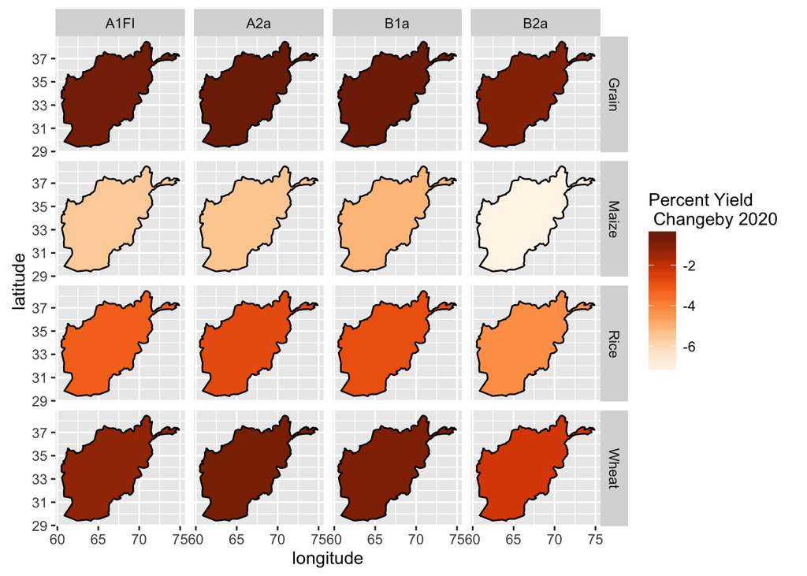

```r
pal1 <- brewer.pal(9, "Oranges")
#Using RColorBrewer function "brewer.pal()" to create a palette of 9 colors from the Oranges scheme. You can also manually list colors to create a palette.

  p = ggplot() +
      geom_polygon(data = Worldshapes.filtered,
        aes(x = long, y = lat, group = group, fill = (value)),
        color = "black") +
      scale_fill_gradientn(name="Percent Yield \n Changeby 2020", colors = pal1) +
      facet_grid(crop~scenario) +
      xlab("longitude") +
      ylab("latitude")

 p
```

Another visualization :

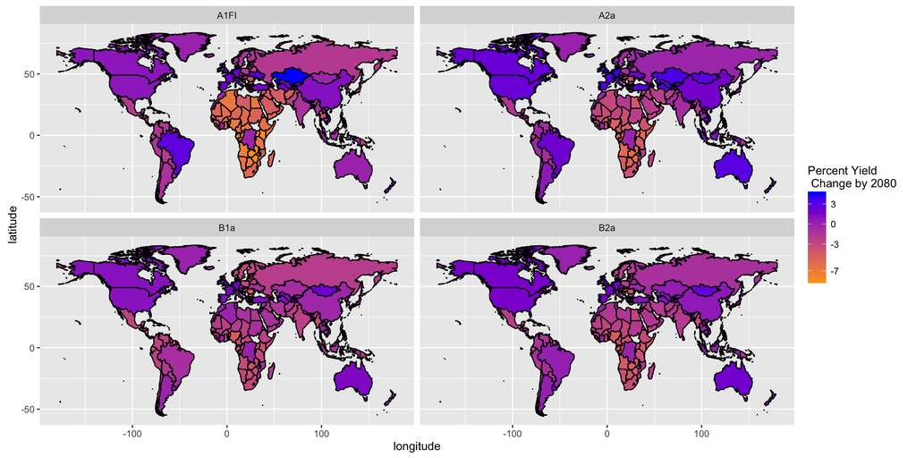

```r
Worldshapes.filtered.2 <-  filter(Worldshapes3, measure == "YieldChange", year == 2080, crop == "Grain")

 p = ggplot() +
      geom_polygon(data = Worldshapes.filtered.2,
        aes(x = long, y = lat, group = group, fill = (value)),
        color = "black") +
      scale_fill_continuous(name="Percent Yield \n Change by 2080",
       low = "orange", high = "blue",
        breaks=c(-7,-3,0, 3)) + #to set this range, I used information from the   command range(Worldshapes.filtered.2$value)
      facet_wrap(~scenario) +
      xlab("longitude") +
      ylab("latitude")

 p
```

*Tip : Use the zoom button to see a larger image of the figure.*

- **What am I plotting here?**
- **Work through the code and annotate what is going on.**
- **Play around with the low and high values in the scale for more/less effective color gradients**
- **What trends do you notice in the figure?**

### Widgets!

Just to introduce you to some other cool packages that can be synced with R, we’ll introduce the concept of widgets - interactive elements often found in websites. For example, if you are using electronic handouts or websites, you may want to be able to zoom in, click on objects, or have maps update according to user inputs. This can be made possible with the use of HTML widgets. The leaflet package is a great tool for rendering dynamic maps with various interactive elements.

Below is some code which allows users to click on countries to see country name and overall grain yield change in 2080 under the A1FI scenario using the leaflet package.

```r
Worldshapes.Yield_20_A1FI <- Worldshapes3 %>% filter(measure == "YieldChange",
                                                     crop == "Grain",
                                                     year == 2080,
                                                     scenario == "A1FI")

test = Worldshapes.Yield_20_A1FI %>% group_by(Country) %>%
  summarize(lat = mean(lat), # summarizing to one central latitude
            long = mean(long), # summarizing to one central longitude
            value = min(value)) # summarizing to one value - all values should be the same within a country, so min() is just used to get to one value.
```

```r
leaflet() %>%
    addTiles() %>%  # addTiles()  Add background map
    setView(lng = 75, lat = 37, zoom = 4) %>%  # setView() Set where the map should originally zoom to
    addCircleMarkers(data = test,
        lat = ~lat, lng = ~long,
        popup = paste(test$value, "%", test$Country))
```

[interactive chart not shown]

For more information about leaflet : https://rstudio.github.io/leaflet/

### On Your Own

Answer the following questions together in your group, by splitting up work and then sharing results. When plotting, keep in mind that you are trying to communicate trends effectively.

- Plot the percent change over time for total change in grain production under each of the emissions scenarios.
  - What trends do you see?
  - Which scenario is the most impactful on grain production?
  - Which areas of the world are most impacted by future climate change?
- Pick a country, research to find the main grain it produces, and visualize actual (not percent yield) changes in the production of that crop over time for each scenario. What trends do you see? Which scenario is the most impactful on grain production?
- Subset the data to include only a specific continent. How does grain percent yield change over time for the A1FI scenario?
- Come up with a question of your own that you can answer by visualizing this data with a map. Then answer it!
- Come up with a plan to statistically test your question. You do not need to carry out the plan, but I would like you to discuss your plan with me.

### Additional Mapping Strategies

There is another way of working with maps, without using shapefiles. This method uses ggplot2 and the maps package (which contains several data files that allow for map creation). A tutorial for this method is found here : http://web.grinnell.edu/individuals/kuipers/stat2labs/Handouts/RTutorials/IntroMakingMaps7_25.html